# Bootstrapping Regression Metrics

Sam Beighle

07 March, 2023

```r
d <- read_tsv(paste(here(),"satisfaction_survey.txt",sep="/"))
```

## Introduction

In this assignment we use bootstrapping to estimate the standard error of several regression coefficients. We did this in class with adjusted R-squared.

In the past few assignments I’ve created most of the framework for you and asked you to fill in pieces that I’ve left blank. This assignment is different. I’ll ask you use techniques we’ve discussed to answer some questions that I’ll ask, but you’ll be doing most of the coding and writing on your own. Feel free to use this actual RMD file for your writing, but now you’ll need to know how to do code blocks and things like that. If you’re anything like me, you’ll find the [R Markdown Cheat Sheet](https://github.com/rstudio/cheatsheets/raw/master/rmarkdown-2.0.pdf) invaluable. Please write this document with attention to things like headers, spelling, and formatting. It need not be as polished as a formal report, but I’ll ask you to revise it if it looks like garbage. I’m not expecting a ton of writing here, but I’d like it to look nice. Remember to knit your document to HTML and commit both your RMD and HTMLfiles.

## Assignment

Here is what I’d like you do:

1. Begin by building a regression model using the satisfaction survey data. Have your model predict satisfaction as a function of tenure and assigned sex. This is the model we built in class.

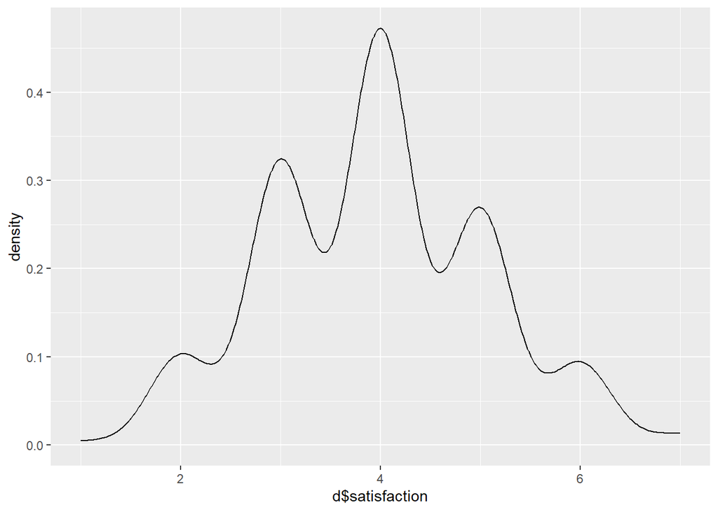

```r
ggplot(d, aes(x=d$satisfaction)) +
  geom_density()
```

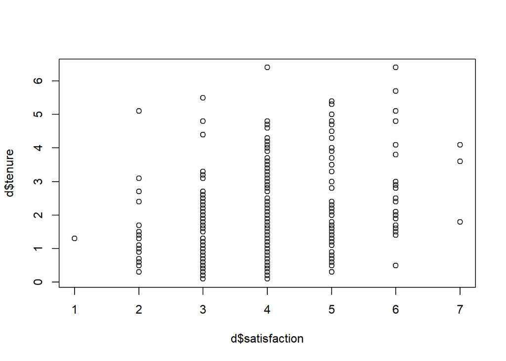

```r
plot(d$satisfaction,d$tenure)
```

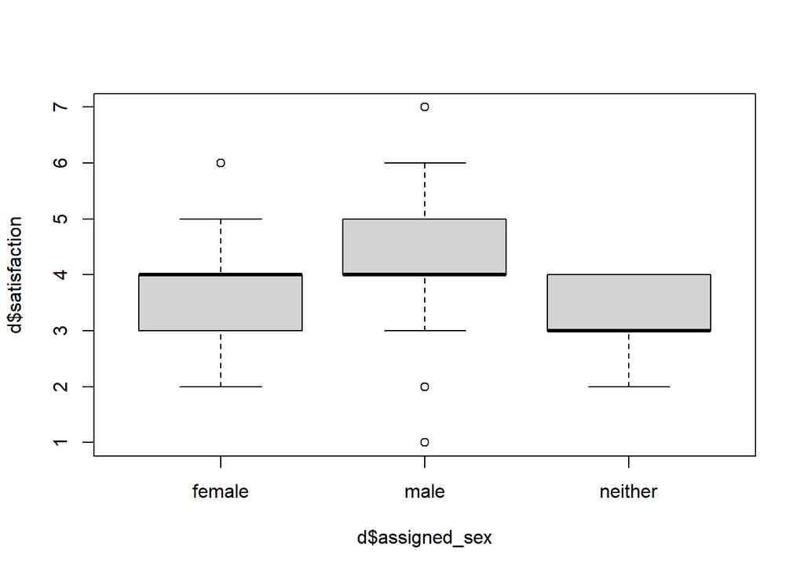

```r
boxplot(d$satisfaction ~d$assigned_sex)
```

```r
#creating lm
d.lm <- lm(satisfaction ~ tenure + assigned_sex, data= d)
summary(d.lm)
```

```
##
## Call:
## lm(formula = satisfaction ~ tenure + assigned_sex, data = d)
##
## Residuals:
##      Min       1Q   Median       3Q      Max
## -3.02602 -0.67298 -0.03716  0.73169  2.86257
##
## Coefficients:
##                     Estimate Std. Error t value Pr(>|t|)
## (Intercept)          3.18278    0.12949  24.580  < 2e-16 ***
## tenure               0.22282    0.04339   5.136 5.11e-07 ***
## assigned_sexmale     0.55358    0.12321   4.493 1.01e-05 ***
## assigned_sexneither -0.36852    0.33507  -1.100    0.272
## ---
## Signif. codes:  0 '***' 0.001 '**' 0.01 '*' 0.05 '.' 0.1 ' ' 1
##
## Residual standard error: 1.013 on 296 degrees of freedom
## Multiple R-squared:  0.1524, Adjusted R-squared:  0.1439
## F-statistic: 17.75 on 3 and 296 DF,  p-value: 1.28e-10
```

1. Describe the results briefly. This means reporting the $R^2$, the residual standard errors, the coefficients and their standard errors. This model should have four terms, with one each for the intercept and tenure and two for assigned sex.

This model has an adjusted $R^2$ of 0.144 suggesting that about 14% of the variability in satisfaction is explained by the model with tenure and assigned sex. With a one year increase in tenure, satisfaction is expected to go up 0.223.The standard error is 0.0434. The intercept for assigned_sex male is 0.554 which means, on average, males have a higher satisfaction than females by 0.554. The standard error is 0.123. Also, it is important to note that the p-values are only significant for the intercept, tenure, and assigned_sex male coefficients. The assigned_sex neither coefficient is not significant. The F-statistic is 17.75 on 3 and 296 degrees of freedom with a p-value of 1.28e-10 suggesting that this model is statistically significant.

1. Use bootstrap resampling (either the `rsample` method or the manual method) to generate standard error estimates for the residual standard error and the model terms. Report the 90% confidence interval for these statistics from the bootstrap replicates.
2. Briefly compare the values from `summary.lm` to the bootstrap replicates.

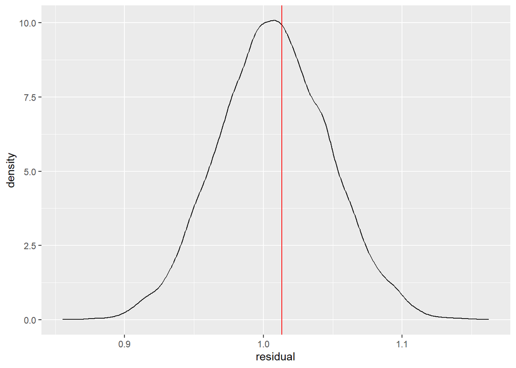

```r
n.sim <- 10000
results <- tibble(
                  residual = rep(NA,n.sim),
                  male.coef = rep(NA,n.sim),
                  Intercept = rep(NA,n.sim),
                  tenure.coef = rep(NA,n.sim),
                  neither.coef =rep(NA,n.sim))

for(i in 1:n.sim){


  new.d <- d %>%
    slice_sample(n=nrow(d),replace=T)

  lm.new <-  lm(satisfaction ~ tenure + assigned_sex,
                data=new.d)

  results$residual[i] <- summary(lm.new)$sigma
  results$male.coef[i] <- summary(lm.new)$coefficients[3,2]
  results$Intercept[i] <- summary(lm.new)$coefficients[1,2]
  results$tenure.coef[i] <- summary(lm.new)$coefficients[2,2]
  results$neither.coef[i] <- summary(lm.new)$coefficients[4,2]
}
#comparing to original lm
ggplot(results,
       aes(x=residual)) +
  geom_density() +
  geom_vline(xintercept = summary(d.lm)$sigma,col="red")
```

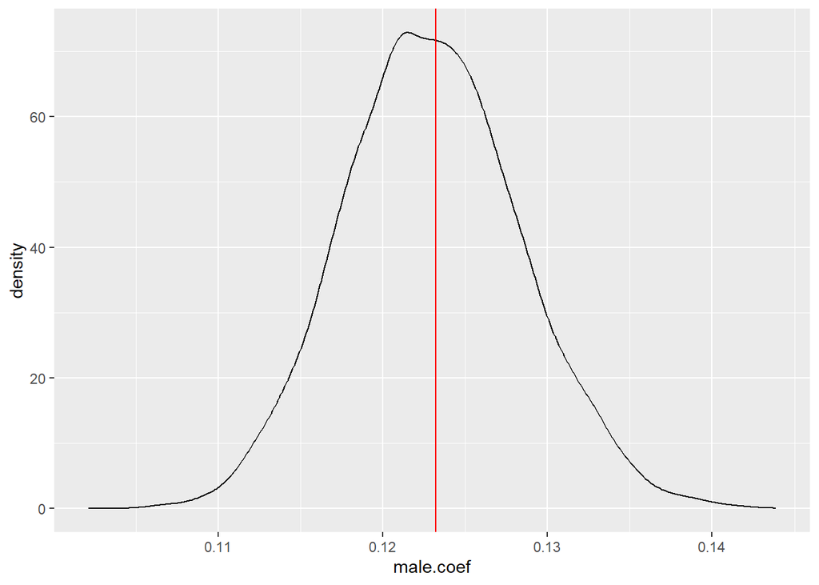

```r
ggplot(results,
       aes(x=male.coef)) +
  geom_density() +
  geom_vline(xintercept = summary(d.lm)$coefficients[3,2],col="red")
```

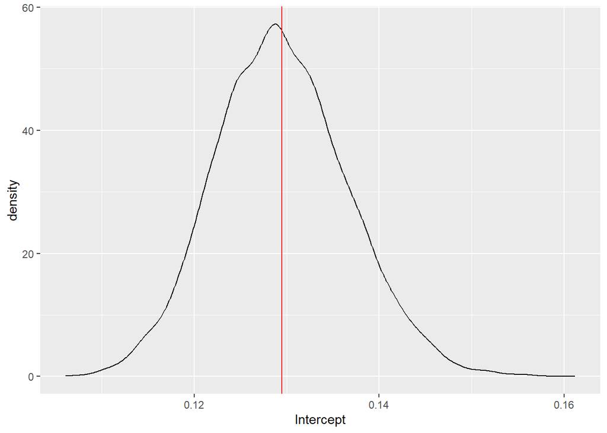

```r
ggplot(results,
       aes(x=Intercept)) +
  geom_density() +
  geom_vline(xintercept = summary(d.lm)$coefficients[1,2],col="red")
```

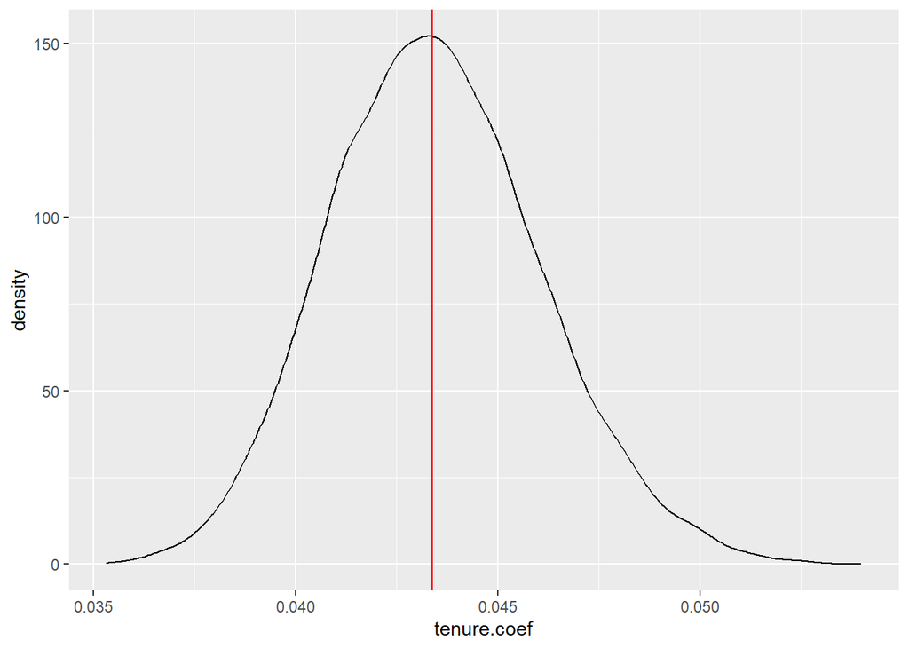

```r
ggplot(results,
       aes(x=tenure.coef)) +
  geom_density() +
  geom_vline(xintercept = summary(d.lm)$coefficients[2,2],col="red")
```

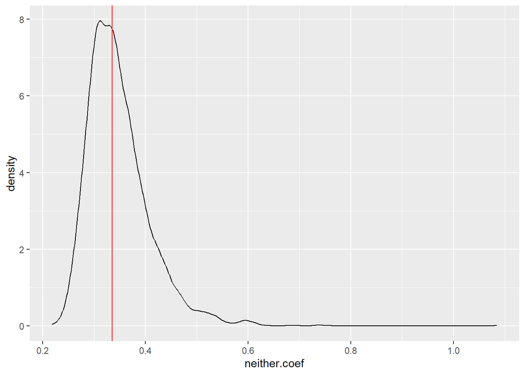

```r
ggplot(results,
       aes(x=neither.coef)) +
  geom_density() +
  geom_vline(xintercept = summary(d.lm)$coefficients[4,2],col="red")
```

```r
# 90% confidence intervals
residual_ci <- quantile(results$residual, prob= c(0.05, 0.95))
intercept_ci <- quantile(results$Intercept, prob= c(0.05, 0.95))
male.coef_ci <- quantile(results$male.coef,prob = c(0.05, 0.95))
tenure.coef_ci <- quantile(results$tenure.coef,prob = c(0.05, 0.95))
neither.coef_ci <- quantile(results$neither.coef,prob=c(0.05,0.95))
```

```r
#significance of categorical variable anova
anova <- anova(d.lm)
anova
```

```
## Analysis of Variance Table
##
## Response: satisfaction
##               Df  Sum Sq Mean Sq F value    Pr(>F)
## tenure         1  28.969 28.9688  28.213 2.139e-07 ***
## assigned_sex   2  25.696 12.8481  12.513 6.072e-06 ***
## Residuals    296 303.932  1.0268
## ---
## Signif. codes:  0 '***' 0.001 '**' 0.01 '*' 0.05 '.' 0.1 ' ' 1
```

In order to test the significance of assigned_sex, an anova was called on the model. The anova shows an f-value of 12..513 and a p-value of 6.072e-06 providing evidence to reject the null hypothesis that there is not relationship between assigned sex and satisfaction. Therefore, we can conclude that there is a relationship between assigned sex and satisfaction based on this analysis.

### Conclusion

As always, please me know if you have any questions. Feel free to ask on Teams so that your classmates benefit from your curiosity or confusion.